# Risk Factor Analysis

## Outcome Variable

**Outcome Variable:** ever_stunted

## Predictor Variables

**Intervention Variable:** feducyrs

**Adjustment Set:**

unadjusted

## Stratifying Variables

The analysis was stratified on these variable(s):

- agecat
- studyid
- country

## Data Summary

| agecat | studyid | country | A | n | nA | nAY0 | nAY1 |
| --- | --- | --- | --- | --- | --- | --- | --- |
| 3 months | ki0047075b-MAL-ED | BANGLADESH | Q4 | 149 | 54 | 40 | 14 |
| 3 months | ki0047075b-MAL-ED | BANGLADESH | Q1 | 149 | 31 | 23 | 8 |
| 3 months | ki0047075b-MAL-ED | BANGLADESH | Q2 | 149 | 9 | 5 | 4 |
| 3 months | ki0047075b-MAL-ED | BANGLADESH | Q3 | 149 | 55 | 38 | 17 |
| 3 months | ki0047075b-MAL-ED | INDIA | Q4 | 147 | 44 | 31 | 13 |
| 3 months | ki0047075b-MAL-ED | INDIA | Q1 | 147 | 25 | 18 | 7 |
| 3 months | ki0047075b-MAL-ED | INDIA | Q2 | 147 | 45 | 38 | 7 |
| 3 months | ki0047075b-MAL-ED | INDIA | Q3 | 147 | 33 | 26 | 7 |
| 3 months | ki0047075b-MAL-ED | NEPAL | Q4 | 98 | 42 | 36 | 6 |
| 3 months | ki0047075b-MAL-ED | NEPAL | Q1 | 98 | 24 | 21 | 3 |
| 3 months | ki0047075b-MAL-ED | NEPAL | Q2 | 98 | 25 | 19 | 6 |
| 3 months | ki0047075b-MAL-ED | NEPAL | Q3 | 98 | 7 | 6 | 1 |
| 3 months | ki0047075b-MAL-ED | PERU | Q4 | 250 | 120 | 77 | 43 |
| 3 months | ki0047075b-MAL-ED | PERU | Q1 | 250 | 51 | 35 | 16 |
| 3 months | ki0047075b-MAL-ED | PERU | Q2 | 250 | 66 | 44 | 22 |
| 3 months | ki0047075b-MAL-ED | PERU | Q3 | 250 | 13 | 10 | 3 |
| 3 months | ki0047075b-MAL-ED | SOUTH AFRICA | Q4 | 110 | 43 | 30 | 13 |
| 3 months | ki0047075b-MAL-ED | SOUTH AFRICA | Q1 | 110 | 19 | 18 | 1 |
| 3 months | ki0047075b-MAL-ED | SOUTH AFRICA | Q2 | 110 | 28 | 22 | 6 |
| 3 months | ki0047075b-MAL-ED | SOUTH AFRICA | Q3 | 110 | 20 | 13 | 7 |
| 3 months | ki0047075b-MAL-ED | TANZANIA, UNITED REPUBLIC OF | Q4 | 212 | 9 | 8 | 1 |
| 3 months | ki0047075b-MAL-ED | TANZANIA, UNITED REPUBLIC OF | Q1 | 212 | 45 | 31 | 14 |
| 3 months | ki0047075b-MAL-ED | TANZANIA, UNITED REPUBLIC OF | Q2 | 212 | 37 | 21 | 16 |
| 3 months | ki0047075b-MAL-ED | TANZANIA, UNITED REPUBLIC OF | Q3 | 212 | 121 | 90 | 31 |
| 3 months | ki1000304b-SAS-CompFeed | INDIA | Q4 | 468 | 122 | 90 | 32 |
| 3 months | ki1000304b-SAS-CompFeed | INDIA | Q1 | 468 | 108 | 63 | 45 |
| 3 months | ki1000304b-SAS-CompFeed | INDIA | Q2 | 468 | 116 | 75 | 41 |
| 3 months | ki1000304b-SAS-CompFeed | INDIA | Q3 | 468 | 122 | 85 | 37 |
| 3 months | ki1017093b-PROVIDE | BANGLADESH | Q4 | 700 | 18 | 15 | 3 |
| 3 months | ki1017093b-PROVIDE | BANGLADESH | Q1 | 700 | 317 | 245 | 72 |

[output cut: 350 more lines]

The following strata were considered:

- agecat: 12 months, studyid: ki0047075b-MAL-ED, country: BANGLADESH
- agecat: 12 months, studyid: ki0047075b-MAL-ED, country: INDIA
- agecat: 12 months, studyid: ki0047075b-MAL-ED, country: NEPAL
- agecat: 12 months, studyid: ki0047075b-MAL-ED, country: PERU
- agecat: 12 months, studyid: ki0047075b-MAL-ED, country: SOUTH AFRICA
- agecat: 12 months, studyid: ki0047075b-MAL-ED, country: TANZANIA, UNITED REPUBLIC OF
- agecat: 12 months, studyid: ki1000304b-SAS-CompFeed, country: INDIA
- agecat: 12 months, studyid: ki1000304b-SAS-FoodSuppl, country: INDIA
- agecat: 12 months, studyid: ki1017093b-PROVIDE, country: BANGLADESH
- agecat: 12 months, studyid: ki1017093c-NIH-Crypto, country: BANGLADESH
- agecat: 12 months, studyid: ki1066203-TanzaniaChild2, country: TANZANIA, UNITED REPUBLIC OF
- agecat: 12 months, studyid: ki1113344-GMS-Nepal, country: NEPAL
- agecat: 12 months, studyid: ki1119695-PROBIT, country: BELARUS
- agecat: 12 months, studyid: ki1126311-ZVITAMBO, country: ZIMBABWE
- agecat: 12 months, studyid: ki1135781-COHORTS, country: GUATEMALA
- agecat: 12 months, studyid: ki1135781-COHORTS, country: INDIA
- agecat: 12 months, studyid: ki1135781-COHORTS, country: PHILIPPINES
- agecat: 12 months, studyid: ki1148112-LCNI-5, country: MALAWI
- agecat: 12 months, studyid: kiGH5241-JiVitA-3, country: BANGLADESH
- agecat: 12 months, studyid: kiGH5241-JiVitA-4, country: BANGLADESH
- agecat: 18 months, studyid: ki0047075b-MAL-ED, country: BANGLADESH
- agecat: 18 months, studyid: ki0047075b-MAL-ED, country: INDIA
- agecat: 18 months, studyid: ki0047075b-MAL-ED, country: NEPAL
- agecat: 18 months, studyid: ki0047075b-MAL-ED, country: PERU
- agecat: 18 months, studyid: ki0047075b-MAL-ED, country: SOUTH AFRICA
- agecat: 18 months, studyid: ki0047075b-MAL-ED, country: TANZANIA, UNITED REPUBLIC OF
- agecat: 18 months, studyid: ki1000304b-SAS-CompFeed, country: INDIA
- agecat: 18 months, studyid: ki1000304b-SAS-FoodSuppl, country: INDIA
- agecat: 18 months, studyid: ki1017093b-PROVIDE, country: BANGLADESH
- agecat: 18 months, studyid: ki1017093c-NIH-Crypto, country: BANGLADESH
- agecat: 18 months, studyid: ki1066203-TanzaniaChild2, country: TANZANIA, UNITED REPUBLIC OF
- agecat: 18 months, studyid: ki1113344-GMS-Nepal, country: NEPAL
- agecat: 18 months, studyid: ki1119695-PROBIT, country: BELARUS
- agecat: 18 months, studyid: ki1126311-ZVITAMBO, country: ZIMBABWE
- agecat: 18 months, studyid: ki1135781-COHORTS, country: GUATEMALA
- agecat: 18 months, studyid: ki1135781-COHORTS, country: PHILIPPINES
- agecat: 18 months, studyid: ki1148112-LCNI-5, country: MALAWI
- agecat: 18 months, studyid: kiGH5241-JiVitA-3, country: BANGLADESH
- agecat: 18 months, studyid: kiGH5241-JiVitA-4, country: BANGLADESH
- agecat: 24 months, studyid: ki0047075b-MAL-ED, country: BANGLADESH
- agecat: 24 months, studyid: ki0047075b-MAL-ED, country: INDIA
- agecat: 24 months, studyid: ki0047075b-MAL-ED, country: NEPAL
- agecat: 24 months, studyid: ki0047075b-MAL-ED, country: PERU
- agecat: 24 months, studyid: ki0047075b-MAL-ED, country: SOUTH AFRICA
- agecat: 24 months, studyid: ki0047075b-MAL-ED, country: TANZANIA, UNITED REPUBLIC OF
- agecat: 24 months, studyid: ki1000304b-SAS-CompFeed, country: INDIA
- agecat: 24 months, studyid: ki1000304b-SAS-FoodSuppl, country: INDIA
- agecat: 24 months, studyid: ki1017093b-PROVIDE, country: BANGLADESH
- agecat: 24 months, studyid: ki1017093c-NIH-Crypto, country: BANGLADESH
- agecat: 24 months, studyid: ki1066203-TanzaniaChild2, country: TANZANIA, UNITED REPUBLIC OF
- agecat: 24 months, studyid: ki1113344-GMS-Nepal, country: NEPAL
- agecat: 24 months, studyid: ki1119695-PROBIT, country: BELARUS
- agecat: 24 months, studyid: ki1126311-ZVITAMBO, country: ZIMBABWE
- agecat: 24 months, studyid: ki1135781-COHORTS, country: GUATEMALA
- agecat: 24 months, studyid: ki1135781-COHORTS, country: PHILIPPINES
- agecat: 24 months, studyid: ki1148112-LCNI-5, country: MALAWI
- agecat: 24 months, studyid: kiGH5241-JiVitA-3, country: BANGLADESH
- agecat: 24 months, studyid: kiGH5241-JiVitA-4, country: BANGLADESH
- agecat: 3 months, studyid: ki0047075b-MAL-ED, country: BANGLADESH
- agecat: 3 months, studyid: ki0047075b-MAL-ED, country: INDIA
- agecat: 3 months, studyid: ki0047075b-MAL-ED, country: NEPAL
- agecat: 3 months, studyid: ki0047075b-MAL-ED, country: PERU
- agecat: 3 months, studyid: ki0047075b-MAL-ED, country: SOUTH AFRICA
- agecat: 3 months, studyid: ki0047075b-MAL-ED, country: TANZANIA, UNITED REPUBLIC OF
- agecat: 3 months, studyid: ki1000304b-SAS-CompFeed, country: INDIA
- agecat: 3 months, studyid: ki1017093b-PROVIDE, country: BANGLADESH
- agecat: 3 months, studyid: ki1017093c-NIH-Crypto, country: BANGLADESH
- agecat: 3 months, studyid: ki1066203-TanzaniaChild2, country: TANZANIA, UNITED REPUBLIC OF
- agecat: 3 months, studyid: ki1113344-GMS-Nepal, country: NEPAL
- agecat: 3 months, studyid: ki1119695-PROBIT, country: BELARUS
- agecat: 3 months, studyid: ki1126311-ZVITAMBO, country: ZIMBABWE
- agecat: 3 months, studyid: ki1135781-COHORTS, country: GUATEMALA
- agecat: 3 months, studyid: ki1135781-COHORTS, country: INDIA
- agecat: 3 months, studyid: ki1135781-COHORTS, country: PHILIPPINES
- agecat: 3 months, studyid: kiGH5241-JiVitA-3, country: BANGLADESH
- agecat: 3 months, studyid: kiGH5241-JiVitA-4, country: BANGLADESH
- agecat: 6 months, studyid: ki0047075b-MAL-ED, country: BANGLADESH
- agecat: 6 months, studyid: ki0047075b-MAL-ED, country: INDIA
- agecat: 6 months, studyid: ki0047075b-MAL-ED, country: NEPAL
- agecat: 6 months, studyid: ki0047075b-MAL-ED, country: PERU
- agecat: 6 months, studyid: ki0047075b-MAL-ED, country: SOUTH AFRICA
- agecat: 6 months, studyid: ki0047075b-MAL-ED, country: TANZANIA, UNITED REPUBLIC OF
- agecat: 6 months, studyid: ki1000304b-SAS-CompFeed, country: INDIA
- agecat: 6 months, studyid: ki1000304b-SAS-FoodSuppl, country: INDIA
- agecat: 6 months, studyid: ki1017093b-PROVIDE, country: BANGLADESH
- agecat: 6 months, studyid: ki1017093c-NIH-Crypto, country: BANGLADESH
- agecat: 6 months, studyid: ki1066203-TanzaniaChild2, country: TANZANIA, UNITED REPUBLIC OF
- agecat: 6 months, studyid: ki1113344-GMS-Nepal, country: NEPAL
- agecat: 6 months, studyid: ki1119695-PROBIT, country: BELARUS
- agecat: 6 months, studyid: ki1126311-ZVITAMBO, country: ZIMBABWE
- agecat: 6 months, studyid: ki1135781-COHORTS, country: GUATEMALA
- agecat: 6 months, studyid: ki1135781-COHORTS, country: PHILIPPINES
- agecat: 6 months, studyid: ki1148112-LCNI-5, country: MALAWI
- agecat: 6 months, studyid: kiGH5241-JiVitA-3, country: BANGLADESH
- agecat: 6 months, studyid: kiGH5241-JiVitA-4, country: BANGLADESH

### Dropped Strata

Some strata were dropped due to rare outcomes:

- agecat: 3 months, studyid: ki0047075b-MAL-ED, country: BANGLADESH
- agecat: 3 months, studyid: ki0047075b-MAL-ED, country: NEPAL
- agecat: 3 months, studyid: ki0047075b-MAL-ED, country: PERU
- agecat: 3 months, studyid: ki0047075b-MAL-ED, country: SOUTH AFRICA
- agecat: 3 months, studyid: ki0047075b-MAL-ED, country: TANZANIA, UNITED REPUBLIC OF
- agecat: 3 months, studyid: ki1017093b-PROVIDE, country: BANGLADESH
- agecat: 3 months, studyid: ki1066203-TanzaniaChild2, country: TANZANIA, UNITED REPUBLIC OF
- agecat: 3 months, studyid: ki1119695-PROBIT, country: BELARUS
- agecat: 3 months, studyid: ki1135781-COHORTS, country: GUATEMALA
- agecat: 3 months, studyid: kiGH5241-JiVitA-4, country: BANGLADESH
- agecat: 6 months, studyid: ki0047075b-MAL-ED, country: BANGLADESH
- agecat: 6 months, studyid: ki0047075b-MAL-ED, country: NEPAL
- agecat: 6 months, studyid: ki0047075b-MAL-ED, country: PERU
- agecat: 6 months, studyid: ki0047075b-MAL-ED, country: SOUTH AFRICA
- agecat: 6 months, studyid: ki0047075b-MAL-ED, country: TANZANIA, UNITED REPUBLIC OF
- agecat: 6 months, studyid: ki1000304b-SAS-FoodSuppl, country: INDIA
- agecat: 6 months, studyid: ki1017093b-PROVIDE, country: BANGLADESH
- agecat: 6 months, studyid: ki1066203-TanzaniaChild2, country: TANZANIA, UNITED REPUBLIC OF
- agecat: 6 months, studyid: ki1119695-PROBIT, country: BELARUS
- agecat: 6 months, studyid: ki1135781-COHORTS, country: GUATEMALA
- agecat: 6 months, studyid: kiGH5241-JiVitA-4, country: BANGLADESH
- agecat: 12 months, studyid: ki0047075b-MAL-ED, country: BANGLADESH
- agecat: 12 months, studyid: ki0047075b-MAL-ED, country: NEPAL
- agecat: 12 months, studyid: ki0047075b-MAL-ED, country: TANZANIA, UNITED REPUBLIC OF
- agecat: 12 months, studyid: ki1000304b-SAS-FoodSuppl, country: INDIA
- agecat: 12 months, studyid: ki1017093b-PROVIDE, country: BANGLADESH
- agecat: 12 months, studyid: ki1066203-TanzaniaChild2, country: TANZANIA, UNITED REPUBLIC OF
- agecat: 12 months, studyid: ki1119695-PROBIT, country: BELARUS
- agecat: 12 months, studyid: ki1135781-COHORTS, country: GUATEMALA
- agecat: 18 months, studyid: ki0047075b-MAL-ED, country: BANGLADESH
- agecat: 18 months, studyid: ki0047075b-MAL-ED, country: NEPAL
- agecat: 18 months, studyid: ki0047075b-MAL-ED, country: PERU
- agecat: 18 months, studyid: ki0047075b-MAL-ED, country: TANZANIA, UNITED REPUBLIC OF
- agecat: 18 months, studyid: ki1000304b-SAS-FoodSuppl, country: INDIA
- agecat: 18 months, studyid: ki1017093b-PROVIDE, country: BANGLADESH
- agecat: 18 months, studyid: ki1066203-TanzaniaChild2, country: TANZANIA, UNITED REPUBLIC OF
- agecat: 18 months, studyid: ki1119695-PROBIT, country: BELARUS
- agecat: 18 months, studyid: ki1135781-COHORTS, country: GUATEMALA
- agecat: 24 months, studyid: ki0047075b-MAL-ED, country: BANGLADESH
- agecat: 24 months, studyid: ki0047075b-MAL-ED, country: NEPAL
- agecat: 24 months, studyid: ki0047075b-MAL-ED, country: PERU
- agecat: 24 months, studyid: ki0047075b-MAL-ED, country: SOUTH AFRICA
- agecat: 24 months, studyid: ki0047075b-MAL-ED, country: TANZANIA, UNITED REPUBLIC OF
- agecat: 24 months, studyid: ki1000304b-SAS-CompFeed, country: INDIA
- agecat: 24 months, studyid: ki1000304b-SAS-FoodSuppl, country: INDIA
- agecat: 24 months, studyid: ki1017093b-PROVIDE, country: BANGLADESH
- agecat: 24 months, studyid: ki1066203-TanzaniaChild2, country: TANZANIA, UNITED REPUBLIC OF
- agecat: 24 months, studyid: ki1119695-PROBIT, country: BELARUS
- agecat: 24 months, studyid: ki1126311-ZVITAMBO, country: ZIMBABWE
- agecat: 24 months, studyid: ki1135781-COHORTS, country: GUATEMALA
- agecat: 24 months, studyid: kiGH5241-JiVitA-3, country: BANGLADESH
- agecat: 24 months, studyid: kiGH5241-JiVitA-4, country: BANGLADESH

## Methods Detail

We’re interested in the causal parameters $E[Y_a]$ for all values of $a \in \mathcal{A}$. These parameters represent the mean outcome if, possibly contrary to fact, we intervened to set all units to have $A=a$. Under the randomization and positivity assumptions, these are identified by the statistical parameters $\psi_a=E_W[E_{Y|A,W}(Y|A=a,W)]$. In addition, we’re interested in the mean of $Y$, $E[Y]$ under no intervention (the observed mean). We will estimate these parameters by using SuperLearner to fit the relevant likelihood factors – $E_{Y|A,W}(Y|A=a,W)$ and $p(A=a|W)$, and then updating our likelihood fit using a joint TMLE.

For unadjusted analyses ($W=\{\}$), initial likelihoods were estimated using Lrnr_glm to estimate the simple $E(Y|A)$ and Lrnr_mean to estimate $p(A)$. For adjusted analyses, a small library containing Lrnr_glmnet, Lrnr_xgboost, and Lrnr_mean was used.

Having estimated these parameters, we will then use the delta method to estimate relative risks and attributable risks relative to a prespecified baseline level of $A$.

# Results Detail

## Results Plots

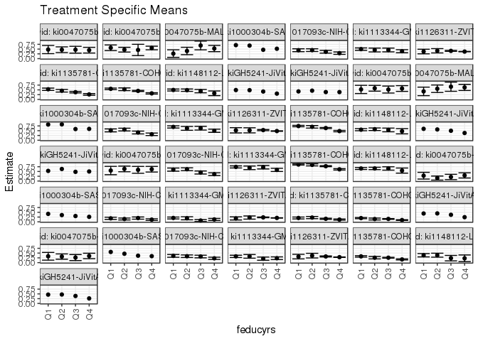

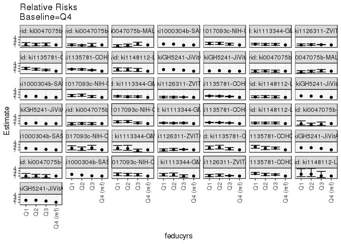

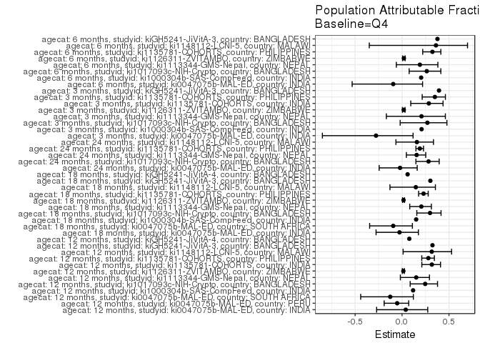

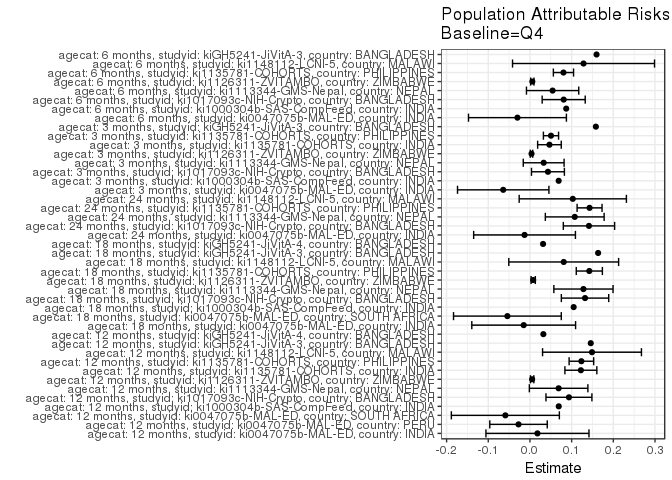

## Results Table

### Parameter: TSM

| agecat | studyid | country | intervention_level | baseline_level | estimate | ci_lower | ci_upper |
| --- | --- | --- | --- | --- | --- | --- | --- |
| 3 months | ki0047075b-MAL-ED | INDIA | Q4 | NA | 0.2954545 | 0.1601838 | 0.4307253 |
| 3 months | ki0047075b-MAL-ED | INDIA | Q1 | NA | 0.2800000 | 0.1033939 | 0.4566061 |
| 3 months | ki0047075b-MAL-ED | INDIA | Q2 | NA | 0.1555556 | 0.0492998 | 0.2618113 |
| 3 months | ki0047075b-MAL-ED | INDIA | Q3 | NA | 0.2121212 | 0.0721641 | 0.3520784 |
| 3 months | ki1000304b-SAS-CompFeed | INDIA | Q4 | NA | 0.2622951 | NA | NA |
| 3 months | ki1000304b-SAS-CompFeed | INDIA | Q1 | NA | 0.4166667 | NA | NA |
| 3 months | ki1000304b-SAS-CompFeed | INDIA | Q2 | NA | 0.3534483 | NA | NA |
| 3 months | ki1000304b-SAS-CompFeed | INDIA | Q3 | NA | 0.3032787 | NA | NA |
| 3 months | ki1017093c-NIH-Crypto | BANGLADESH | Q4 | NA | 0.1165049 | 0.0726644 | 0.1603453 |
| 3 months | ki1017093c-NIH-Crypto | BANGLADESH | Q1 | NA | 0.1839080 | 0.1263070 | 0.2415090 |
| 3 months | ki1017093c-NIH-Crypto | BANGLADESH | Q2 | NA | 0.1479592 | 0.0982189 | 0.1976994 |
| 3 months | ki1017093c-NIH-Crypto | BANGLADESH | Q3 | NA | 0.1978022 | 0.1398920 | 0.2557124 |
| 3 months | ki1113344-GMS-Nepal | NEPAL | Q4 | NA | 0.1258741 | 0.0714612 | 0.1802871 |
| 3 months | ki1113344-GMS-Nepal | NEPAL | Q1 | NA | 0.2023346 | 0.1531766 | 0.2514926 |
| 3 months | ki1113344-GMS-Nepal | NEPAL | Q2 | NA | 0.1868132 | 0.1066650 | 0.2669613 |
| 3 months | ki1113344-GMS-Nepal | NEPAL | Q3 | NA | 0.0693069 | 0.0197338 | 0.1188800 |
| 3 months | ki1126311-ZVITAMBO | ZIMBABWE | Q4 | NA | 0.2046934 | 0.1973747 | 0.2120121 |
| 3 months | ki1126311-ZVITAMBO | ZIMBABWE | Q1 | NA | 0.1785714 | 0.0966655 | 0.2604773 |
| 3 months | ki1126311-ZVITAMBO | ZIMBABWE | Q2 | NA | 0.2244898 | 0.1418778 | 0.3071018 |
| 3 months | ki1126311-ZVITAMBO | ZIMBABWE | Q3 | NA | 0.2334262 | 0.2138565 | 0.2529959 |
| 3 months | ki1135781-COHORTS | INDIA | Q4 | NA | 0.1172070 | 0.0857125 | 0.1487015 |
| 3 months | ki1135781-COHORTS | INDIA | Q1 | NA | 0.2015810 | 0.1521294 | 0.2510327 |
| 3 months | ki1135781-COHORTS | INDIA | Q2 | NA | 0.2243902 | 0.1672624 | 0.2815181 |
| 3 months | ki1135781-COHORTS | INDIA | Q3 | NA | 0.1583630 | 0.1281689 | 0.1885571 |
| 3 months | ki1135781-COHORTS | PHILIPPINES | Q4 | NA | 0.0937500 | 0.0739406 | 0.1135594 |
| 3 months | ki1135781-COHORTS | PHILIPPINES | Q1 | NA | 0.1955128 | 0.1643900 | 0.2266356 |
| 3 months | ki1135781-COHORTS | PHILIPPINES | Q2 | NA | 0.1470588 | 0.0984502 | 0.1956675 |
| 3 months | ki1135781-COHORTS | PHILIPPINES | Q3 | NA | 0.1518883 | 0.1317284 | 0.1720483 |
| 3 months | kiGH5241-JiVitA-3 | BANGLADESH | Q4 | NA | 0.2436364 | NA | NA |
| 3 months | kiGH5241-JiVitA-3 | BANGLADESH | Q1 | NA | 0.4366715 | NA | NA |

[output cut: 142 more lines]

### Parameter: E(Y)

| agecat | studyid | country | intervention_level | baseline_level | estimate | ci_lower | ci_upper |
| --- | --- | --- | --- | --- | --- | --- | --- |
| 3 months | ki0047075b-MAL-ED | INDIA | NA | NA | 0.2312925 | 0.1628962 | 0.2996889 |
| 3 months | ki1000304b-SAS-CompFeed | INDIA | NA | NA | 0.3311966 | NA | NA |
| 3 months | ki1017093c-NIH-Crypto | BANGLADESH | NA | NA | 0.1596306 | 0.1335394 | 0.1857218 |
| 3 months | ki1113344-GMS-Nepal | NEPAL | NA | NA | 0.1587838 | 0.1293185 | 0.1882491 |
| 3 months | ki1126311-ZVITAMBO | ZIMBABWE | NA | NA | 0.2084524 | 0.2016385 | 0.2152662 |
| 3 months | ki1135781-COHORTS | INDIA | NA | NA | 0.1639690 | 0.1447117 | 0.1832264 |
| 3 months | ki1135781-COHORTS | PHILIPPINES | NA | NA | 0.1441974 | 0.1313609 | 0.1570338 |
| 3 months | kiGH5241-JiVitA-3 | BANGLADESH | NA | NA | 0.4017552 | NA | NA |
| 6 months | ki0047075b-MAL-ED | INDIA | NA | NA | 0.3188406 | 0.2408039 | 0.3968773 |
| 6 months | ki1000304b-SAS-CompFeed | INDIA | NA | NA | 0.4273973 | NA | NA |
| 6 months | ki1017093c-NIH-Crypto | BANGLADESH | NA | NA | 0.3070652 | 0.2737175 | 0.3404129 |
| 6 months | ki1113344-GMS-Nepal | NEPAL | NA | NA | 0.2862191 | 0.2489494 | 0.3234888 |
| 6 months | ki1126311-ZVITAMBO | ZIMBABWE | NA | NA | 0.2922467 | 0.2827629 | 0.3017306 |
| 6 months | ki1135781-COHORTS | PHILIPPINES | NA | NA | 0.2483980 | 0.2319532 | 0.2648429 |
| 6 months | ki1148112-LCNI-5 | MALAWI | NA | NA | 0.3558052 | 0.2982716 | 0.4133389 |
| 6 months | kiGH5241-JiVitA-3 | BANGLADESH | NA | NA | 0.4236081 | NA | NA |
| 12 months | ki0047075b-MAL-ED | INDIA | NA | NA | 0.4598540 | 0.3760926 | 0.5436155 |
| 12 months | ki0047075b-MAL-ED | PERU | NA | NA | 0.5291480 | 0.4634878 | 0.5948082 |
| 12 months | ki0047075b-MAL-ED | SOUTH AFRICA | NA | NA | 0.4687500 | 0.3684025 | 0.5690975 |
| 12 months | ki1000304b-SAS-CompFeed | INDIA | NA | NA | 0.5862884 | NA | NA |
| 12 months | ki1017093c-NIH-Crypto | BANGLADESH | NA | NA | 0.3799726 | 0.3447141 | 0.4152311 |
| 12 months | ki1113344-GMS-Nepal | NEPAL | NA | NA | 0.4561102 | 0.4155757 | 0.4966446 |
| 12 months | ki1126311-ZVITAMBO | ZIMBABWE | NA | NA | 0.3741407 | 0.3646043 | 0.3836771 |
| 12 months | ki1135781-COHORTS | INDIA | NA | NA | 0.3847795 | 0.3593387 | 0.4102203 |
| 12 months | ki1135781-COHORTS | PHILIPPINES | NA | NA | 0.4402757 | 0.4212345 | 0.4593168 |
| 12 months | ki1148112-LCNI-5 | MALAWI | NA | NA | 0.4702908 | 0.4354862 | 0.5050954 |
| 12 months | kiGH5241-JiVitA-3 | BANGLADESH | NA | NA | 0.4500187 | NA | NA |
| 12 months | kiGH5241-JiVitA-4 | BANGLADESH | NA | NA | 0.4167726 | NA | NA |
| 18 months | ki0047075b-MAL-ED | INDIA | NA | NA | 0.5563910 | 0.4716387 | 0.6411432 |
| 18 months | ki0047075b-MAL-ED | SOUTH AFRICA | NA | NA | 0.5744681 | 0.4739821 | 0.6749541 |
| 18 months | ki1000304b-SAS-CompFeed | INDIA | NA | NA | 0.6980676 | NA | NA |
| 18 months | ki1017093c-NIH-Crypto | BANGLADESH | NA | NA | 0.4433566 | 0.4069178 | 0.4797954 |
| 18 months | ki1113344-GMS-Nepal | NEPAL | NA | NA | 0.6247818 | 0.5851033 | 0.6644604 |
| 18 months | ki1126311-ZVITAMBO | ZIMBABWE | NA | NA | 0.4882403 | 0.4765779 | 0.4999027 |
| 18 months | ki1135781-COHORTS | PHILIPPINES | NA | NA | 0.6214372 | 0.6023863 | 0.6404881 |
| 18 months | ki1148112-LCNI-5 | MALAWI | NA | NA | 0.5515695 | 0.5138551 | 0.5892839 |
| 18 months | kiGH5241-JiVitA-3 | BANGLADESH | NA | NA | 0.5423825 | NA | NA |
| 18 months | kiGH5241-JiVitA-4 | BANGLADESH | NA | NA | 0.5314136 | NA | NA |
| 24 months | ki0047075b-MAL-ED | INDIA | NA | NA | 0.6060606 | 0.5223876 | 0.6897336 |
| 24 months | ki1017093c-NIH-Crypto | BANGLADESH | NA | NA | 0.5015773 | 0.4626267 | 0.5405279 |
| 24 months | ki1113344-GMS-Nepal | NEPAL | NA | NA | 0.6913580 | 0.6533024 | 0.7294137 |
| 24 months | ki1135781-COHORTS | PHILIPPINES | NA | NA | 0.7557756 | 0.7386690 | 0.7728821 |
| 24 months | ki1148112-LCNI-5 | MALAWI | NA | NA | 0.6499303 | 0.6149919 | 0.6848686 |

### Parameter: RR

| agecat | studyid | country | intervention_level | baseline_level | estimate | ci_lower | ci_upper |
| --- | --- | --- | --- | --- | --- | --- | --- |
| 3 months | ki0047075b-MAL-ED | INDIA | Q4 | Q4 | 1.0000000 | 1.0000000 | 1.000000 |
| 3 months | ki0047075b-MAL-ED | INDIA | Q1 | Q4 | 0.9476923 | 0.4346941 | 2.066098 |
| 3 months | ki0047075b-MAL-ED | INDIA | Q2 | Q4 | 0.5264957 | 0.2313488 | 1.198181 |
| 3 months | ki0047075b-MAL-ED | INDIA | Q3 | Q4 | 0.7179487 | 0.3216005 | 1.602766 |
| 3 months | ki1000304b-SAS-CompFeed | INDIA | Q4 | Q4 | 1.0000000 | NA | NA |
| 3 months | ki1000304b-SAS-CompFeed | INDIA | Q1 | Q4 | 1.5885417 | NA | NA |
| 3 months | ki1000304b-SAS-CompFeed | INDIA | Q2 | Q4 | 1.3475216 | NA | NA |
| 3 months | ki1000304b-SAS-CompFeed | INDIA | Q3 | Q4 | 1.1562500 | NA | NA |
| 3 months | ki1017093c-NIH-Crypto | BANGLADESH | Q4 | Q4 | 1.0000000 | 1.0000000 | 1.000000 |
| 3 months | ki1017093c-NIH-Crypto | BANGLADESH | Q1 | Q4 | 1.5785441 | 0.9674553 | 2.575624 |
| 3 months | ki1017093c-NIH-Crypto | BANGLADESH | Q2 | Q4 | 1.2699830 | 0.7667542 | 2.103486 |
| 3 months | ki1017093c-NIH-Crypto | BANGLADESH | Q3 | Q4 | 1.6978022 | 1.0539668 | 2.734936 |
| 3 months | ki1113344-GMS-Nepal | NEPAL | Q4 | Q4 | 1.0000000 | 1.0000000 | 1.000000 |
| 3 months | ki1113344-GMS-Nepal | NEPAL | Q1 | Q4 | 1.6074362 | 0.9789881 | 2.639308 |
| 3 months | ki1113344-GMS-Nepal | NEPAL | Q2 | Q4 | 1.4841270 | 0.8071747 | 2.728818 |
| 3 months | ki1113344-GMS-Nepal | NEPAL | Q3 | Q4 | 0.5506051 | 0.2387146 | 1.269993 |
| 3 months | ki1126311-ZVITAMBO | ZIMBABWE | Q4 | Q4 | 1.0000000 | 1.0000000 | 1.000000 |
| 3 months | ki1126311-ZVITAMBO | ZIMBABWE | Q1 | Q4 | 0.8723849 | 0.5506868 | 1.382011 |
| 3 months | ki1126311-ZVITAMBO | ZIMBABWE | Q2 | Q4 | 1.0967125 | 0.7577403 | 1.587323 |
| 3 months | ki1126311-ZVITAMBO | ZIMBABWE | Q3 | Q4 | 1.1403699 | 1.0410294 | 1.249190 |
| 3 months | ki1135781-COHORTS | INDIA | Q4 | Q4 | 1.0000000 | 1.0000000 | 1.000000 |
| 3 months | ki1135781-COHORTS | INDIA | Q1 | Q4 | 1.7198722 | 1.1953051 | 2.474649 |
| 3 months | ki1135781-COHORTS | INDIA | Q2 | Q4 | 1.9144785 | 1.3221798 | 2.772110 |
| 3 months | ki1135781-COHORTS | INDIA | Q3 | Q4 | 1.3511395 | 0.9718717 | 1.878415 |
| 3 months | ki1135781-COHORTS | PHILIPPINES | Q4 | Q4 | 1.0000000 | 1.0000000 | 1.000000 |
| 3 months | ki1135781-COHORTS | PHILIPPINES | Q1 | Q4 | 2.0854700 | 1.6007017 | 2.717049 |
| 3 months | ki1135781-COHORTS | PHILIPPINES | Q2 | Q4 | 1.5686274 | 1.0596040 | 2.322180 |
| 3 months | ki1135781-COHORTS | PHILIPPINES | Q3 | Q4 | 1.6201422 | 1.2623625 | 2.079324 |
| 3 months | kiGH5241-JiVitA-3 | BANGLADESH | Q4 | Q4 | 1.0000000 | NA | NA |
| 3 months | kiGH5241-JiVitA-3 | BANGLADESH | Q1 | Q4 | 1.7923082 | NA | NA |

[output cut: 142 more lines]

### Parameter: PAR

| agecat | studyid | country | intervention_level | baseline_level | estimate | ci_lower | ci_upper |
| --- | --- | --- | --- | --- | --- | --- | --- |
| 3 months | ki0047075b-MAL-ED | INDIA | Q4 | NA | -0.0641620 | -0.1738079 | 0.0454839 |
| 3 months | ki1000304b-SAS-CompFeed | INDIA | Q4 | NA | 0.0689015 | NA | NA |
| 3 months | ki1017093c-NIH-Crypto | BANGLADESH | Q4 | NA | 0.0431258 | 0.0036534 | 0.0825981 |
| 3 months | ki1113344-GMS-Nepal | NEPAL | Q4 | NA | 0.0329097 | -0.0160659 | 0.0818852 |
| 3 months | ki1126311-ZVITAMBO | ZIMBABWE | Q4 | NA | 0.0037590 | 0.0008647 | 0.0066533 |
| 3 months | ki1135781-COHORTS | INDIA | Q4 | NA | 0.0467621 | 0.0184261 | 0.0750980 |
| 3 months | ki1135781-COHORTS | PHILIPPINES | Q4 | NA | 0.0504474 | 0.0322732 | 0.0686215 |
| 3 months | kiGH5241-JiVitA-3 | BANGLADESH | Q4 | NA | 0.1581188 | NA | NA |
| 6 months | ki0047075b-MAL-ED | INDIA | Q4 | NA | -0.0299966 | -0.1474363 | 0.0874430 |
| 6 months | ki1000304b-SAS-CompFeed | INDIA | Q4 | NA | 0.0869717 | NA | NA |
| 6 months | ki1017093c-NIH-Crypto | BANGLADESH | Q4 | NA | 0.0809346 | 0.0293058 | 0.1325633 |
| 6 months | ki1113344-GMS-Nepal | NEPAL | Q4 | NA | 0.0543350 | -0.0083857 | 0.1170558 |
| 6 months | ki1126311-ZVITAMBO | ZIMBABWE | Q4 | NA | 0.0056638 | 0.0016685 | 0.0096591 |
| 6 months | ki1135781-COHORTS | PHILIPPINES | Q4 | NA | 0.0803873 | 0.0561492 | 0.1046254 |
| 6 months | ki1148112-LCNI-5 | MALAWI | Q4 | NA | 0.1285325 | -0.0418149 | 0.2988799 |
| 6 months | kiGH5241-JiVitA-3 | BANGLADESH | Q4 | NA | 0.1597583 | NA | NA |
| 12 months | ki0047075b-MAL-ED | INDIA | Q4 | NA | 0.0179935 | -0.1056107 | 0.1415978 |
| 12 months | ki0047075b-MAL-ED | PERU | Q4 | NA | -0.0274558 | -0.0964082 | 0.0414966 |
| 12 months | ki0047075b-MAL-ED | SOUTH AFRICA | Q4 | NA | -0.0590278 | -0.1885971 | 0.0705416 |
| 12 months | ki1000304b-SAS-CompFeed | INDIA | Q4 | NA | 0.0690470 | NA | NA |
| 12 months | ki1017093c-NIH-Crypto | BANGLADESH | Q4 | NA | 0.0935404 | 0.0384309 | 0.1486499 |
| 12 months | ki1113344-GMS-Nepal | NEPAL | Q4 | NA | 0.0687862 | -0.0014303 | 0.1390027 |
| 12 months | ki1126311-ZVITAMBO | ZIMBABWE | Q4 | NA | 0.0052318 | 0.0011814 | 0.0092821 |
| 12 months | ki1135781-COHORTS | INDIA | Q4 | NA | 0.1221533 | 0.0838363 | 0.1604702 |
| 12 months | ki1135781-COHORTS | PHILIPPINES | Q4 | NA | 0.1234032 | 0.0939633 | 0.1528432 |
| 12 months | ki1148112-LCNI-5 | MALAWI | Q4 | NA | 0.1488622 | 0.0302407 | 0.2674837 |
| 12 months | kiGH5241-JiVitA-3 | BANGLADESH | Q4 | NA | 0.1458611 | NA | NA |
| 12 months | kiGH5241-JiVitA-4 | BANGLADESH | Q4 | NA | 0.0321572 | NA | NA |
| 18 months | ki0047075b-MAL-ED | INDIA | Q4 | NA | -0.0150376 | -0.1395277 | 0.1094525 |
| 18 months | ki0047075b-MAL-ED | SOUTH AFRICA | Q4 | NA | -0.0541033 | -0.1833715 | 0.0751648 |
| 18 months | ki1000304b-SAS-CompFeed | INDIA | Q4 | NA | 0.1048473 | NA | NA |
| 18 months | ki1017093c-NIH-Crypto | BANGLADESH | Q4 | NA | 0.1321322 | 0.0753131 | 0.1889512 |
| 18 months | ki1113344-GMS-Nepal | NEPAL | Q4 | NA | 0.1283279 | 0.0573399 | 0.1993160 |
| 18 months | ki1126311-ZVITAMBO | ZIMBABWE | Q4 | NA | 0.0077953 | 0.0027036 | 0.0128869 |
| 18 months | ki1135781-COHORTS | PHILIPPINES | Q4 | NA | 0.1424213 | 0.1111028 | 0.1737397 |
| 18 months | ki1148112-LCNI-5 | MALAWI | Q4 | NA | 0.0809813 | -0.0507404 | 0.2127029 |
| 18 months | kiGH5241-JiVitA-3 | BANGLADESH | Q4 | NA | 0.1635560 | NA | NA |
| 18 months | kiGH5241-JiVitA-4 | BANGLADESH | Q4 | NA | 0.0314136 | NA | NA |
| 24 months | ki0047075b-MAL-ED | INDIA | Q4 | NA | -0.0129870 | -0.1350711 | 0.1090971 |
| 24 months | ki1017093c-NIH-Crypto | BANGLADESH | Q4 | NA | 0.1415773 | 0.0800447 | 0.2031099 |
| 24 months | ki1113344-GMS-Nepal | NEPAL | Q4 | NA | 0.1074164 | 0.0368843 | 0.1779486 |
| 24 months | ki1135781-COHORTS | PHILIPPINES | Q4 | NA | 0.1430159 | 0.1131294 | 0.1729025 |
| 24 months | ki1148112-LCNI-5 | MALAWI | Q4 | NA | 0.1027605 | -0.0258703 | 0.2313913 |

### Parameter: PAF

| agecat | studyid | country | intervention_level | baseline_level | estimate | ci_lower | ci_upper |
| --- | --- | --- | --- | --- | --- | --- | --- |
| 3 months | ki0047075b-MAL-ED | INDIA | Q4 | NA | -0.2774064 | -0.8490161 | 0.1174943 |
| 3 months | ki1000304b-SAS-CompFeed | INDIA | Q4 | NA | 0.2080381 | NA | NA |
| 3 months | ki1017093c-NIH-Crypto | BANGLADESH | Q4 | NA | 0.2701597 | -0.0201482 | 0.4778534 |
| 3 months | ki1113344-GMS-Nepal | NEPAL | Q4 | NA | 0.2072608 | -0.1673042 | 0.4616353 |
| 3 months | ki1126311-ZVITAMBO | ZIMBABWE | Q4 | NA | 0.0180327 | 0.0040555 | 0.0318138 |
| 3 months | ki1135781-COHORTS | INDIA | Q4 | NA | 0.2851883 | 0.0926855 | 0.4368483 |
| 3 months | ki1135781-COHORTS | PHILIPPINES | Q4 | NA | 0.3498494 | 0.2144500 | 0.4619109 |
| 3 months | kiGH5241-JiVitA-3 | BANGLADESH | Q4 | NA | 0.3935701 | NA | NA |
| 6 months | ki0047075b-MAL-ED | INDIA | Q4 | NA | -0.0940803 | -0.5320251 | 0.2186735 |
| 6 months | ki1000304b-SAS-CompFeed | INDIA | Q4 | NA | 0.2034915 | NA | NA |
| 6 months | ki1017093c-NIH-Crypto | BANGLADESH | Q4 | NA | 0.2635745 | 0.0757619 | 0.4132221 |
| 6 months | ki1113344-GMS-Nepal | NEPAL | Q4 | NA | 0.1898372 | -0.0611569 | 0.3814639 |
| 6 months | ki1126311-ZVITAMBO | ZIMBABWE | Q4 | NA | 0.0193802 | 0.0056161 | 0.0329537 |
| 6 months | ki1135781-COHORTS | PHILIPPINES | Q4 | NA | 0.3236229 | 0.2201668 | 0.4133540 |
| 6 months | ki1148112-LCNI-5 | MALAWI | Q4 | NA | 0.3612440 | -0.3493887 | 0.6976340 |
| 6 months | kiGH5241-JiVitA-3 | BANGLADESH | Q4 | NA | 0.3771371 | NA | NA |
| 12 months | ki0047075b-MAL-ED | INDIA | Q4 | NA | 0.0391288 | -0.2711012 | 0.2736429 |
| 12 months | ki0047075b-MAL-ED | PERU | Q4 | NA | -0.0518868 | -0.1908558 | 0.0708650 |
| 12 months | ki0047075b-MAL-ED | SOUTH AFRICA | Q4 | NA | -0.1259259 | -0.4408815 | 0.1201850 |
| 12 months | ki1000304b-SAS-CompFeed | INDIA | Q4 | NA | 0.1177697 | NA | NA |
| 12 months | ki1017093c-NIH-Crypto | BANGLADESH | Q4 | NA | 0.2461767 | 0.0864152 | 0.3780002 |
| 12 months | ki1113344-GMS-Nepal | NEPAL | Q4 | NA | 0.1508105 | -0.0182695 | 0.2918154 |
| 12 months | ki1126311-ZVITAMBO | ZIMBABWE | Q4 | NA | 0.0139834 | 0.0030969 | 0.0247510 |
| 12 months | ki1135781-COHORTS | INDIA | Q4 | NA | 0.3174630 | 0.2106252 | 0.4098408 |
| 12 months | ki1135781-COHORTS | PHILIPPINES | Q4 | NA | 0.2802863 | 0.2100552 | 0.3442734 |
| 12 months | ki1148112-LCNI-5 | MALAWI | Q4 | NA | 0.3165323 | 0.0111289 | 0.5276147 |
| 12 months | kiGH5241-JiVitA-3 | BANGLADESH | Q4 | NA | 0.3241224 | NA | NA |
| 12 months | kiGH5241-JiVitA-4 | BANGLADESH | Q4 | NA | 0.0771576 | NA | NA |
| 18 months | ki0047075b-MAL-ED | INDIA | Q4 | NA | -0.0270270 | -0.2770901 | 0.1740719 |
| 18 months | ki0047075b-MAL-ED | SOUTH AFRICA | Q4 | NA | -0.0941799 | -0.3454564 | 0.1101684 |
| 18 months | ki1000304b-SAS-CompFeed | INDIA | Q4 | NA | 0.1501965 | NA | NA |
| 18 months | ki1017093c-NIH-Crypto | BANGLADESH | Q4 | NA | 0.2980268 | 0.1570941 | 0.4153957 |
| 18 months | ki1113344-GMS-Nepal | NEPAL | Q4 | NA | 0.2053964 | 0.0818355 | 0.3123292 |
| 18 months | ki1126311-ZVITAMBO | ZIMBABWE | Q4 | NA | 0.0159660 | 0.0054758 | 0.0263456 |
| 18 months | ki1135781-COHORTS | PHILIPPINES | Q4 | NA | 0.2291805 | 0.1763048 | 0.2786618 |
| 18 months | ki1148112-LCNI-5 | MALAWI | Q4 | NA | 0.1468197 | -0.1290717 | 0.3552964 |
| 18 months | kiGH5241-JiVitA-3 | BANGLADESH | Q4 | NA | 0.3015510 | NA | NA |
| 18 months | kiGH5241-JiVitA-4 | BANGLADESH | Q4 | NA | 0.0591133 | NA | NA |
| 24 months | ki0047075b-MAL-ED | INDIA | Q4 | NA | -0.0214286 | -0.2441599 | 0.1614291 |
| 24 months | ki1017093c-NIH-Crypto | BANGLADESH | Q4 | NA | 0.2822642 | 0.1474481 | 0.3957614 |
| 24 months | ki1113344-GMS-Nepal | NEPAL | Q4 | NA | 0.1553702 | 0.0458121 | 0.2523490 |
| 24 months | ki1135781-COHORTS | PHILIPPINES | Q4 | NA | 0.1892307 | 0.1477383 | 0.2287030 |
| 24 months | ki1148112-LCNI-5 | MALAWI | Q4 | NA | 0.1581100 | -0.0654939 | 0.3347885 |